# Association rules

Movie recommender systems

Amirabbas Jalali 93105556

2018-07-18 12:40:41

> با استفاده از داده نظرهای فیلم به سوالات زیر پاسخ دهید.

داده ها و کتابخانه های زیر در این تمرین مورد استفاده قرار می گیرند.

```r
library(readr)
library(dplyr)
library(stringr)
library(reshape2)
library(corrplot)
library(wordcloud2)
library(tidytext)
library(arules)
library(arulesViz)
library(colorspace)
library(ggplot2)

movie = read_delim("../../Data/data_classification/ml-10M100K/movies.dat",
                   ":",
                   col_names = c('movie_id', 'a', 'title', 'description', 'genres', 'c')) %>%
  select(-a) %>%
  mutate(genres = ifelse(!is.na(genres), as.character(genres), as.character(c))) %>%
  select(-c) %>%
  mutate(title = ifelse(!is.na(description),
                        paste(title, description, sep=": "),
                        as.character(title))) %>%
  select(-description) %>%
  mutate(year = str_extract(title, '\\([[:digit:]]{4}\\)'),
         year = str_extract(year, '[[:digit:]]{4}'))

movie$Action = 0
movie$Adventure = 0
movie$Animation = 0
movie$Children = 0
movie$Comedy = 0
movie$Crime = 0
movie$Documentary = 0
movie$Drama = 0
movie$Fantasy = 0
movie$`Film-Noir` = 0
movie$Horror = 0
movie$Musical = 0
movie$Mystery = 0
movie$Romance = 0
movie$`Sci-Fi` = 0
movie$Thriller = 0
movie$War = 0
movie$Western = 0

movie = movie %>%
  mutate(Action = ifelse(str_detect(genres, 'Action'),1,0),
         Adventure = ifelse(str_detect(genres, 'Adventure'),1,0),
         Animation = ifelse(str_detect(genres, 'Animation'),1,0),
         Children = ifelse(str_detect(genres, 'Children'),1,0),
         Comedy = ifelse(str_detect(genres, 'Comedy'),1,0),
         Crime = ifelse(str_detect(genres, 'Crime'),1,0),
         Documentary = ifelse(str_detect(genres, 'Documentary'),1,0),
         Drama = ifelse(str_detect(genres, 'Drama'),1,0),
         Fantasy = ifelse(str_detect(genres, 'Fantasy'),1,0),
         `Film-Noir` = ifelse(str_detect(genres, 'Film-Noir'),1,0),
          Horror = ifelse(str_detect(genres, 'Horror'),1,0),
         Musical = ifelse(str_detect(genres, 'Musical'),1,0),
         Mystery = ifelse(str_detect(genres, 'Mystery'),1,0),
         Romance = ifelse(str_detect(genres, 'Romance'),1,0),
         `Sci-Fi` = ifelse(str_detect(genres, 'Sci-Fi'),1,0),
         Thriller = ifelse(str_detect(genres, 'Thriller'),1,0),
         War = ifelse(str_detect(genres, 'War'),1,0),
         Western = ifelse(str_detect(genres, 'Western'),1,0))

movie_name = movie %>%
  select(movie_id, title) %>%
  distinct(movie_id, title)

rating = read_delim("../../Data/data_classification/ml-10M100K/ratings.dat",
                   ":",
                   col_names = c('user_id', 'a', 'movie_id', 'b', 'rating', 'c', 'timestamp')) %>%
  select(-a, -b, -c)

tag = read_delim("../../Data/data_classification/ml-10M100K/tags.dat",
                   ":",
                   col_names = c('user_id', 'a', 'movie_id', 'b', 'tag', 'c', 'timestamp')) %>%
  select(-a, -b, -c)
```

۱. آماره های زیر را بیابید.

الف. محبوب ترین فیلم کدام است؟

```r
top_10_movies = rating %>%
  group_by(movie_id) %>%
  summarise(mean_rating = mean(rating), voted = n()) %>%
  mutate(score = mean_rating*voted) %>%
  arrange(-score) %>%
  filter(mean_rating > 4.2) %>%
  slice(1:10) %>%
  arrange(-mean_rating)

top_10_movies = merge(top_10_movies, movie_name, sort = FALSE)
knitr::kable(top_10_movies, "html")
```

| movie_id | mean_rating | voted | score | title |
| --- | --- | --- | --- | --- |
| 318 | 4.457238 | 31126 | 138736.0 | Shawshank Redemption, The (1994) |
| 858 | 4.415085 | 19814 | 87480.5 | Godfather, The (1972) |
| 50 | 4.367142 | 24037 | 104973.0 | Usual Suspects, The (1995) |
| 527 | 4.363483 | 25777 | 112477.5 | Schindler’s List (1993) |
| 1193 | 4.292380 | 14435 | 61960.5 | One Flew Over the Cuckoo’s Nest (1975) |
| 1198 | 4.261317 | 21803 | 92909.5 | Raiders of the Lost Ark (Indiana Jones and the Raiders of the Lost Ark) (1981) |
| 260 | 4.220209 | 28566 | 120554.5 | Star Wars: Episode IV - A New Hope (a.k.a. Star Wars) (1977) |
| 1136 | 4.206132 | 16242 | 68316.0 | Monty Python and the Holy Grail (1975) |
| 2571 | 4.205132 | 23229 | 97681.0 | Matrix, The (1999) |
| 593 | 4.204200 | 33668 | 141547.0 | Silence of the Lambs, The (1991) |

ب. بیشترین نظرات درباره چه فیلمی داده شده است؟

```r
most_comments = rating %>%
  group_by(movie_id) %>%
  summarise(voted = n()) %>%
  arrange(-voted) %>%
  slice(1)

most_comments = merge(most_comments, movie_name, sort = FALSE)
knitr::kable(most_comments, "html")
```

| movie_id | voted | title |
| --- | --- | --- |
| 296 | 34864 | Pulp Fiction (1994) |

پ. منفورترین فیلم کدام است؟

```r
worst_movie = rating %>%
  group_by(movie_id) %>%
  summarise(mean_rating = mean(rating), voted = n()) %>%
  filter(voted > 1000) %>%
  arrange(mean_rating, -voted) %>%
  slice(1)

worst_movie = merge(worst_movie, movie_name, sort = FALSE)
knitr::kable(worst_movie, "html")
```

| movie_id | mean_rating | voted | title |
| --- | --- | --- | --- |
| 3593 | 1.577703 | 2072 | Battlefield Earth (2000) |

ت. تعداد فیلم های ساخته شده در هر سال

```r
most_productive_year = movie %>%
  group_by(year) %>%
  summarise(count = n()) %>%
  na.omit() %>%
  arrange(year)

knitr::kable(most_productive_year, "html")
```

| year | count |
| --- | --- |
| 1915 | 1 |
| 1916 | 2 |
| 1917 | 2 |
| 1918 | 2 |
| 1919 | 3 |
| 1920 | 5 |
| 1921 | 3 |
| 1922 | 7 |
| 1923 | 6 |
| 1924 | 6 |
| 1925 | 10 |
| 1926 | 10 |
| 1927 | 18 |
| 1928 | 10 |
| 1929 | 7 |
| 1930 | 15 |
| 1931 | 16 |
| 1932 | 22 |
| 1933 | 23 |
| 1934 | 18 |
| 1935 | 18 |
| 1936 | 32 |
| 1937 | 30 |
| 1938 | 19 |
| 1939 | 37 |
| 1940 | 40 |
| 1941 | 28 |
| 1942 | 38 |
| 1943 | 40 |
| 1944 | 37 |

[output cut: 64 more lines]

ث. در هر سالی مردم به چه ژانری علاقه مند بوده اند.

برای این سوال ژانری که فیلم در آن ساخته شده را برابر علاقه ی مردم درنظر می گیریم چون فیلم سازان با توجه به علایق جامعه به تولید فیلم می پردازند.

```r
genre_year = movie %>%
  group_by(year) %>%
  select(-movie_id, -genres, -year, -title) %>%
  summarise_all(funs(sum)) %>%
  na.omit()

genre_year$genre_of_year = colnames(genre_year %>% select(-year))[apply(genre_year %>% select(-year), 1, which.max)]

genre_of_the_year = genre_year %>%
  select(year, genre_of_year)

knitr::kable(genre_of_the_year, "html")
```

| year | genre_of_year |
| --- | --- |
| 1915 | Drama |
| 1916 | Action |
| 1917 | Comedy |
| 1918 | Comedy |
| 1919 | Drama |
| 1920 | Drama |
| 1921 | Drama |
| 1922 | Drama |
| 1923 | Comedy |
| 1924 | Comedy |
| 1925 | Drama |
| 1926 | Drama |
| 1927 | Drama |
| 1928 | Comedy |
| 1929 | Drama |
| 1930 | Drama |
| 1931 | Drama |
| 1932 | Drama |
| 1933 | Comedy |
| 1934 | Comedy |
| 1935 | Drama |
| 1936 | Drama |
| 1937 | Drama |
| 1938 | Drama |
| 1939 | Drama |
| 1940 | Drama |
| 1941 | Comedy |
| 1942 | Drama |
| 1943 | Drama |
| 1944 | Drama |

[output cut: 64 more lines]

۲. ژانر فیلم ها را استخراج نمایید. سپس آماره های زیر را استخراج نمایید.

الف. نمودار ستونی تعداد فیلم های هر ژانر

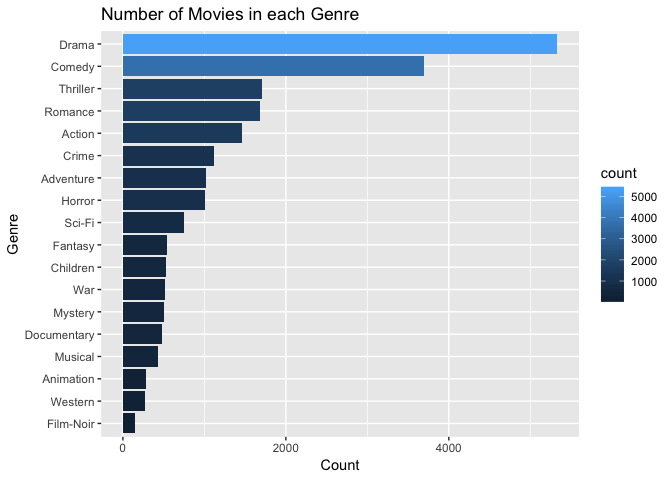

```r
genre_movies = movie %>%
  ungroup() %>%
  select(-movie_id, -genres, -year, -title) %>%
  summarise_all(funs(sum)) %>%
  na.omit()

genre_movies = melt(genre_movies)
colnames(genre_movies) = c('genre', 'count')

ggplot(data = genre_movies, aes(x = reorder(genre, count), y = count, fill = count)) +
  geom_bar(stat="identity") +
  ggtitle("Number of Movies in each Genre") +
  xlab("Genre") +
  ylab("Count") +
  coord_flip()
```

ب. نمودار همبستگی ژانرها

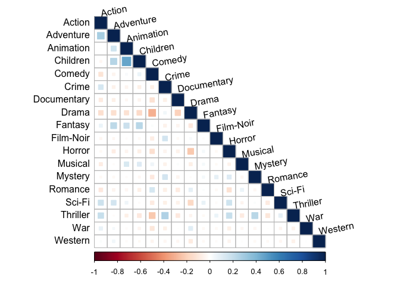

```r
genres = movie %>%
  select(-movie_id, -genres, -year, -title)

cor_genre = cor(genres)
corrplot(cor_genre, method = "square", type = "lower", tl.col = "black", tl.srt = 10)
```

پ. متوسط امتیاز به هر ژانر

```r
genre_avg_rating = rating %>%
  group_by(movie_id) %>%
  summarise(mean_rate = mean(rating))

genre_avg_rating = merge(genre_avg_rating, movie, sort = FALSE) %>%
  select(-movie_id, -title, -genres, -year)

genre_avg_rating[-1] = genre_avg_rating[["mean_rate"]] * genre_avg_rating[-1]

genre_avg_rating = genre_avg_rating %>%
  summarise_all(funs(sum)) %>%
  select(-mean_rate) %>%
  melt()

colnames(genre_avg_rating) = c('genre', 'sum_rate')

genre_avg_rating = merge(genre_avg_rating, genre_movies) %>%
  mutate(avrage_rate = sum_rate/count) %>%
  na.omit() %>%
  arrange(-avrage_rate)

knitr::kable(genre_avg_rating, "html")
```

| genre | sum_rate | count | avrage_rate |
| --- | --- | --- | --- |
| Film-Noir | 545.5449 | 147 | 3.711190 |
| Documentary | 1655.9989 | 479 | 3.457200 |
| War | 1761.8524 | 511 | 3.447852 |
| Drama | 17852.0971 | 5332 | 3.348105 |
| Mystery | 1694.0341 | 509 | 3.328161 |
| Western | 910.4167 | 275 | 3.310606 |
| Romance | 5559.0831 | 1685 | 3.299159 |
| Crime | 3677.3869 | 1116 | 3.295150 |
| Musical | 1419.7751 | 436 | 3.256365 |
| Animation | 919.6616 | 284 | 3.238245 |
| Fantasy | 1737.1406 | 543 | 3.199154 |
| Thriller | 5404.2429 | 1703 | 3.173366 |
| Adventure | 3213.0725 | 1018 | 3.156260 |
| Comedy | 11520.3940 | 3698 | 3.115304 |
| Action | 4464.1640 | 1460 | 3.057647 |
| Children | 1578.8176 | 527 | 2.995859 |
| Sci-Fi | 2228.8007 | 750 | 2.971734 |
| Horror | 2828.4341 | 1012 | 2.794895 |

ت. دوران طلایی فیلم سازی

```r
year_avg_rating = rating %>%
  group_by(movie_id) %>%
  summarise(mean_rate = mean(rating))

year_avg_rating = merge(year_avg_rating, movie, sort = FALSE) %>%
  group_by(year) %>%
  summarise(mean_rate_year = mean(mean_rate), count = n() ) %>%
  mutate(score = mean_rate_year*count) %>%
  arrange(-score) %>%
  slice(1:10) %>%
  arrange(-mean_rate_year)

knitr::kable(year_avg_rating, "html")
```

| year | mean_rate_year | count | score |
| --- | --- | --- | --- |
| 2007 | 3.223033 | 363 | 1169.961 |
| 1996 | 3.161931 | 383 | 1211.019 |
| 1995 | 3.152285 | 362 | 1141.127 |
| 2003 | 3.148552 | 365 | 1149.222 |
| 2002 | 3.135972 | 440 | 1379.828 |
| 2001 | 3.111115 | 401 | 1247.557 |
| 2000 | 3.105126 | 405 | 1257.576 |
| 1998 | 3.095297 | 384 | 1188.594 |
| 1999 | 3.095057 | 357 | 1104.935 |
| 1997 | 3.074784 | 369 | 1134.595 |

۳. نمودار ابر لغات را بر حسب کلمات عنوان فیلم ها رسم نمایید.

```r
movie_titles = movie %>%
  select(title) %>%
  mutate(title = str_to_lower(title)) %>%
  str_replace_all("\"","") %>%
  str_replace_all("\\([[:digit:]]{4}\\)", "") %>%
  str_replace_all("\\d", "") %>%
  str_replace_all("[[:punct:]]", "") %>%
  str_split(pattern = "\\s") %>%
  unlist() %>%
  as.data.frame(stringsAsFactors = F) %>%
  table() %>%
  as.data.frame(stringsAsFactors = F)

colnames(movie_titles) = c("word","freq")

movie_titles = movie_titles %>%
  filter(!(word %in% stop_words$word) & str_length(word)>2) %>%
  arrange(-freq) %>%
  slice(2:900)

wordcloud2(movie_titles, figPath = 'images/film.png', size = 0.6, color = "black")
```

[interactive chart not shown]

۴. با استفاده از قوانین همبستگی یک توصیه گر برای فیلم ها بسازید. شبیه ترین فیلم ها به لیست زیر را پیدا کنید.

- Castle in the Sky (1986)
- Cast Away (2000)
- No Country for Old Men (2007)
- Memento (2000)

تراکنش ها را باتوجه به علایق یک مشتری در دیدن چندین فیلم به دست آورده ام به این صورت که هر شناسه ی هر کاربر شناسه ی یک تراکنش است و فیلم هایی که بالای ۳ نمره دهی کرده محتوای آن تراکنش. بعد از استفاده از قوانین همبستگی و بدست آوردن نام فیلم ها متوجه شدم که فیلم های سمت راست را با فیلم های داده شده تطابق دهم زیرا نتایج بهتری به دست می آورد که نتایج را در جدول می بینیم.

```r
trans = rating %>%
  filter(rating>3) %>%
  select(user_id, movie_id)

trans = unique(trans)
trans = as(split(trans$movie_id, trans[,"user_id"]), "transactions")

as_rules = apriori(trans,parameter = list(supp = 0.001, conf = 0.5, maxlen = 2))
```

```
Apriori

Parameter specification:
 confidence minval smax arem  aval originalSupport maxtime support minlen
        0.5    0.1    1 none FALSE            TRUE       5   0.001      1
 maxlen target   ext
      2  rules FALSE

Algorithmic control:
 filter tree heap memopt load sort verbose
    0.1 TRUE TRUE  FALSE TRUE    2    TRUE

Absolute minimum support count: 69

set item appearances ...[0 item(s)] done [0.00s].
set transactions ...[10472 item(s), 69816 transaction(s)] done [1.94s].
sorting and recoding items ... [5038 item(s)] done [0.15s].
creating transaction tree ... done [0.05s].
checking subsets of size 1 2 done [1.20s].
writing ... [182800 rule(s)] done [0.11s].
creating S4 object  ... done [0.06s].
```

```r
summary(as_rules)
```

```
set of 182800 rules

rule length distribution (lhs + rhs):sizes
     2
182800

   Min. 1st Qu.  Median    Mean 3rd Qu.    Max.
      2       2       2       2       2       2

summary of quality measures:
    support           confidence          lift             count
 Min.   :0.001003   Min.   :0.5000   Min.   :  1.219   Min.   :   70.0
 1st Qu.:0.001547   1st Qu.:0.5368   1st Qu.:  2.292   1st Qu.:  108.0
 Median :0.002764   Median :0.5830   Median :  3.378   Median :  193.0
 Mean   :0.007012   Mean   :0.5995   Mean   :  4.348   Mean   :  489.5
 3rd Qu.:0.006675   3rd Qu.:0.6473   3rd Qu.:  4.860   3rd Qu.:  466.0
 Max.   :0.261989   Max.   :0.9529   Max.   :425.946   Max.   :18291.0

mining info:
  data ntransactions support confidence
 trans         69816   0.001        0.5
```

```r
as_rules = subset(as_rules, lift >= 4.348)
summary(as_rules)
```

```
set of 58113 rules

rule length distribution (lhs + rhs):sizes
    2
58113

   Min. 1st Qu.  Median    Mean 3rd Qu.    Max.
      2       2       2       2       2       2

summary of quality measures:
    support           confidence          lift             count
 Min.   :0.001003   Min.   :0.5000   Min.   :  4.348   Min.   :   70
 1st Qu.:0.001361   1st Qu.:0.5325   1st Qu.:  4.956   1st Qu.:   95
 Median :0.002091   Median :0.5726   Median :  5.825   Median :  146
 Mean   :0.003881   Mean   :0.5919   Mean   :  7.794   Mean   :  271
 3rd Qu.:0.003953   3rd Qu.:0.6335   3rd Qu.:  7.753   3rd Qu.:  276
 Max.   :0.148648   Max.   :0.9529   Max.   :425.946   Max.   :10378

mining info:
  data ntransactions support confidence
 trans         69816   0.001        0.5
```

```r
as_rules = as(as_rules,"data.frame")
movie_rules = as_rules %>%
  mutate(lhs = str_extract(rules, "[[:digit:]]+"),
         rhs = str_extract(rules, " \\{[[:digit:]]+"),
         rhs = str_extract(rhs, "[[:digit:]]+")) %>%
  select(movie_id = lhs, support, lift, confidence, rhs)

movie_rules = merge(movie_name, movie_rules, sort = FALSE)
movie_rules = movie_rules %>%
  select(lhs_movie_name = title, movie_id = rhs, support, lift, confidence, lhs = movie_id )
movie_rules = merge(movie_name, movie_rules, sort = FALSE)
movie_rules = movie_rules %>%
  select(lhs_movie_name, rhs_movie_name = title, lhs, rhs = movie_id, support, confidence, lift)

selected_movie_rules = movie_rules %>%
  filter(lhs_movie_name == "Castle in the Sky (Tenkû no shiro Rapyuta) (1986)" |
           rhs_movie_name == "Castle in the Sky (Tenkû no shiro Rapyuta) (1986)" |
           lhs_movie_name == "Cast Away (2000)" |
           rhs_movie_name == "Cast Away (2000)" |
           lhs_movie_name == "No Country for Old Men (2007)" |
           rhs_movie_name == "No Country for Old Men (2007)" |
           lhs_movie_name == "Memento (2000)" |
           rhs_movie_name == "Memento (2000)"
           )%>%
  group_by(rhs_movie_name) %>%
  arrange(-lift) %>%
  filter(rhs_movie_name == "Castle in the Sky (Tenkû no shiro Rapyuta) (1986)" |
           rhs_movie_name == "Cast Away (2000)" |
           rhs_movie_name == "No Country for Old Men (2007)" |
           rhs_movie_name == "Memento (2000)"
           )%>%
  slice(1) %>%
  select(main_movie = rhs_movie_name, most_simillar_movie = lhs_movie_name)

knitr::kable(selected_movie_rules, "html")
```

| main_movie | most_simillar_movie |
| --- | --- |
| Cast Away (2000) | Out of Time (2003) |
| Castle in the Sky (Tenkû no shiro Rapyuta) (1986) | Castle Of Cagliostro, The (Rupan sansei: Kariosutoro no shiro) (1979) |
| Memento (2000) | Following (1998) |
| No Country for Old Men (2007) | Before the Devil Knows You’re Dead (2007) |

۵. تمرین سخت: در گیت هاب برای خود اکانت درست کنید. همه تمرین های خود را آنجا بارگذاری کنید! و لینک آن را ارسال نمایید.

لینک تمارین: https://github.com/Ajal88/Data_Analysis

۶. پنج انتقاد از درس و نحوه تدریس را بیان کنید.

۱. رویکرد درس از قبل متفاوت تر شده بود و کمتر مهندسی بود به این مفهوم که امتحانات کاملا ریاضی وار برگذار شدند و کمتر اهمیت درک ما از نتایج مورد توجه بود و بیشتر محاسباتی مد نظر بود که در طول تمارین به آن ها هرگز پرداخته نمی شد.  
۲. حجم تمارین و پروژه بی سابقه بود! :)  
۳. خیلی سخت گیرانس ولی خب اسلاید هرچی جلوتر رفتیم کیفیتشون کمتر می شد  
. ۴. تعداد دقیق برای انتقاد خوب نیست، شاید یکی ۶ تا انتقاد خوب داشت!  
۵. پنج تا انتقاد واقعا زیاده ندارم …

۷. پنج پیشنهاد برای بهتر شدن درس بیان کنید.

۱. رویکرد مهندسی رو در این درس دوباره احیا کنید …  
۲. تمارین رو اندکی کاهش دهید.  
۳. ارتباط استادیارها رو با دانشجوها بیشتر کنید و یکم فورسشون کنید اشکالات تمرینات بچه ها رو زودتر بگن نه بعد از اینکه کلا تمرینات یک مبحث تموم میشه.  
۴. نمره ها رو خب زودتر بدید آدم بفهمه چند چنده …  
۵. عدد دقیق کلا برای اینجور سوالا درست نیست به نظرم!

۸. سه موضوع آماری جدید برای جایگزینی در سرفصل ها پیشنهاد دهید.

۹. سه داده جالب برای کار در کلاس پیشنهاد دهید.

۱. رمزارزها رو جای سهام ها بیارید.  
۲. از داده های تلفن های همراه متصل به آنتن ها برای یافتن شلوغی ها و مسیر حرکت مردم روی نقشه.  
۳. انتخابات آمریکا

۱۰. چهار نکته مهمی که در کلاس یاد گرفتید را بیان کنید.

۱. بدون گل قطعا بهار نمیشه!  
۲. خیلی R  
۳. تلاش کنم و زیر بار تمرین ها کمر خم نکنم که بعد از هر سختی آسانیست …:)  
۴. آزمون فرض